# hw1

## Antenna Problem

In designing antennas that effectively transmit and receive signals at specific frequencies, understanding key performance metrics is essential. One such metric is the S11 parameter, also known as "return loss," which measures how much of a signal is reflected back rather than radiated effectively. A low S11 value at desired frequencies indicates efficient radiation, crucial for high-frequency communication systems like those used in 5G technology.

However, evaluating S11 across a wide range of frequencies requires complex electromagnetic simulations, which are computationally intensive and time-consuming. This complexity makes optimizing antenna designs through trial and error challenging, particularly when exploring numerous geometric configurations and material properties.

This assignment aims to explore the relationships between the design parameters of an antenna and its electromagnetic performance using machine learning techniques such as Principal Component Analysis (PCA) and regression modeling. By applying these methods, the goal is to simplify the complex relationships within the S11 dataset, identify influential design parameters, and develop predictive models that can support efficient antenna design and performance analysis.

For this problem there are two types of target variables. The real part of S11 represents how much of the signal’s power is reflected directly back without any time delay.The imaginary part represents how much of the reflected signal is shifted in phase relative to the transmitted signal. Also there are 201 frequencies, for the sack of simplicity 2 key frequencies are selected.

```python
import numpy as np
import pandas as pd
import matplotlib.pyplot as plt
import seaborn as sns
from sklearn.decomposition import PCA
from sklearn.linear_model import LinearRegression
from sklearn.model_selection import train_test_split
from sklearn.metrics import mean_squared_error, r2_score
from sklearn.preprocessing import StandardScaler
import matplotlib.pyplot as plt
```

#### 1.Loading the input and output data

```python
input_data = pd.read_csv('hw1_input.csv')  # Load design parameters
real_data = pd.read_csv('hw1_real.csv')    # Load real part of S11
img_data = pd.read_csv('hw1_img.csv')     # Load imginary part of S11

input_data.head()
```

|  | length of patch | width of patch | height of patch | height of substrate | height of solder resist layer | radius of the probe | c_pad | c_antipad | c_probe | dielectric constant of substrate | dielectric constant of solder resist layer |
| --- | --- | --- | --- | --- | --- | --- | --- | --- | --- | --- | --- |
| 0 | 3.202024 | 2.288742 | 0.012514 | 0.139247 | 0.041757 | 0.028566 | 0.000549 | 0.032403 | 0.348140 | 3.735926 | 4.278575 |
| 1 | 2.107848 | 2.895504 | 0.037171 | 0.149492 | 0.056775 | 0.028930 | 0.005536 | 0.053647 | 0.326369 | 4.929862 | 4.876068 |
| 2 | 3.252113 | 4.818411 | 0.025432 | 0.578834 | 0.029972 | 0.030922 | 0.020274 | 0.049845 | 0.446639 | 4.772670 | 4.745106 |
| 3 | 4.161509 | 2.294309 | 0.011058 | 0.117266 | 0.093223 | 0.017604 | 0.001135 | 0.098610 | 0.055665 | 4.102438 | 3.755671 |
| 4 | 4.820912 | 2.948325 | 0.019658 | 0.163503 | 0.094337 | 0.025757 | 0.021725 | 0.072813 | 0.272282 | 2.531031 | 3.047553 |

```python
print(real_data.head())
```

```
          0         1         2         3         4         5         6  \
0  0.649471  0.608623  0.563770  0.515485  0.464365  0.411022  0.356056
1 -0.684443 -0.680926 -0.677355 -0.673727 -0.670041 -0.666296 -0.662491
2  0.670194  0.678183  0.685886  0.693294  0.700399  0.707191  0.713661
3 -0.856026 -0.854962 -0.853892 -0.852815 -0.851731 -0.850642 -0.849545
4 -0.952876 -0.951901 -0.950906 -0.949892 -0.948860 -0.947811 -0.946747

          7         8         9  ...       191       192       193       194  \
0  0.300044  0.243525  0.186992  ... -0.895451 -0.894250 -0.893045 -0.891835
1 -0.658624 -0.654692 -0.650696  ... -0.835303 -0.832276 -0.829209 -0.826105
2  0.719799  0.725595  0.731037  ...  0.693171  0.675653  0.656992  0.637113
3 -0.848442 -0.847333 -0.846217  ... -0.115205 -0.096197 -0.076456 -0.055953
4 -0.945668 -0.944575 -0.943469  ... -0.692349 -0.690720 -0.689088 -0.687453

        195       196       197       198       199       200
0 -0.890620 -0.889402 -0.888178 -0.886951 -0.885718 -0.884482
1 -0.822965 -0.819791 -0.816584 -0.813346 -0.810078 -0.806782
2  0.615936  0.593384  0.569383  0.543870  0.516796  0.488139
3 -0.034660 -0.012550  0.010402  0.034219  0.058921  0.084521
4 -0.685813 -0.684171 -0.682524 -0.680874 -0.679221 -0.677564

[5 rows x 201 columns]
```

```python
print(img_data.head())
```

```
          0         1         2         3         4         5         6  \
0 -0.435160 -0.493311 -0.547391 -0.597047 -0.642027 -0.682178 -0.717442
1  0.710936  0.714041  0.717157  0.720283  0.723419  0.726566  0.729724
2  0.549842  0.537964  0.525835  0.513455  0.500828  0.487957  0.474844
3  0.507327  0.509092  0.510857  0.512623  0.514389  0.516156  0.517923
4  0.249540  0.254110  0.258618  0.263062  0.267447  0.271772  0.276041

          7         8         9  ...       191       192       193       194  \
0 -0.747848 -0.773501 -0.794570  ...  0.418737  0.421368  0.423987  0.426592
1  0.732892  0.736070  0.739259  ...  0.442050  0.449451  0.456720  0.463863
2  0.461492  0.447904  0.434083  ... -0.518546 -0.534209 -0.549582 -0.564575
3  0.519690  0.521459  0.523228  ...  0.928563  0.927782  0.926488  0.924621
4  0.280253  0.284410  0.288515  ...  0.705500  0.707018  0.708531  0.710037

        195       196       197       198       199       200
0  0.429186  0.431767  0.434335  0.436892  0.439437  0.441969
1  0.470884  0.477786  0.484573  0.491249  0.497816  0.504278
2 -0.579078 -0.592957 -0.606054 -0.618175 -0.629093 -0.638543
3  0.922114  0.918892  0.914873  0.909964  0.904064  0.897060
4  0.711538  0.713034  0.714523  0.716007  0.717486  0.718958

[5 rows x 201 columns]
```

#### 2. Data Preprocessing & PCA

```python
selected_freq_indices = [70,120]
real_selected = real_data.iloc[:, selected_freq_indices]
img_selected = img_data.iloc[:, selected_freq_indices]

# Split data into training and test sets
X_train, X_test, y_train_real, y_test_real = train_test_split(input_data, real_selected, test_size=0.3, random_state=1)
X_train, X_test, y_train_img, y_test_img = train_test_split(input_data, img_selected, test_size=0.3, random_state=1)
X_train.head()
```

|  | length of patch | width of patch | height of patch | height of substrate | height of solder resist layer | radius of the probe | c_pad | c_antipad | c_probe | dielectric constant of substrate | dielectric constant of solder resist layer |
| --- | --- | --- | --- | --- | --- | --- | --- | --- | --- | --- | --- |
| 257 | 1.841867 | 3.323746 | 0.024361 | 0.152341 | 0.093978 | 0.028709 | 0.024357 | 0.054847 | 0.281274 | 2.607205 | 2.370581 |
| 85 | 5.124479 | 5.079565 | 0.024182 | 0.574316 | 0.088570 | 0.021187 | 0.012814 | 0.053097 | 0.110040 | 3.569411 | 4.751679 |
| 58 | 2.621102 | 2.956563 | 0.034738 | 0.108651 | 0.042042 | 0.027216 | 0.002728 | 0.049915 | 0.260321 | 2.861437 | 3.036103 |
| 267 | 3.031712 | 2.086535 | 0.030258 | 0.156652 | 0.032073 | 0.025358 | 0.012916 | 0.028231 | 0.139108 | 3.866295 | 3.998659 |
| 165 | 4.552439 | 4.813174 | 0.012783 | 0.727447 | 0.024881 | 0.020548 | 0.022140 | 0.049651 | 0.296739 | 3.740389 | 4.104888 |

```
Explained variance by each principal component: [0.20714834 0.11121812 0.10869435 0.10224376 0.09342887 0.08728294
 0.08165724 0.07856563 0.06632053 0.05688063 0.00655959]
```

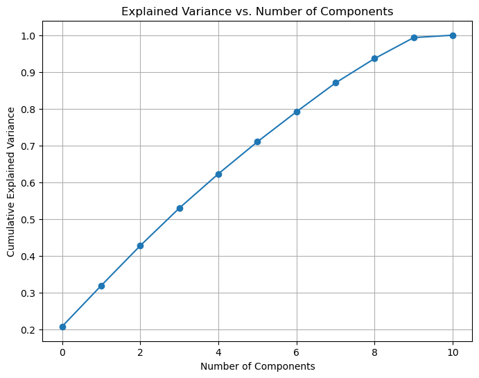

```python
# Scale design parameters based on training data
scaler = StandardScaler()
X_train_scaled = scaler.fit_transform(X_train)
X_test_scaled = scaler.transform(X_test)

# 4. Dimensionality Reduction with PCA
pca = PCA()
X_train_pca = pca.fit_transform(X_train_scaled)
X_test_pca = pca.transform(X_test_scaled)

# Check explained variance ratio
explained_variance = pca.explained_variance_ratio_
print("Explained variance by each principal component:", explained_variance)

# Plot explained variance to determine the number of components
plt.figure(figsize=(8, 6))
plt.plot(np.cumsum(explained_variance), marker='o')
plt.xlabel('Number of Components')
plt.ylabel('Cumulative Explained Variance')
plt.title('Explained Variance vs. Number of Components')
plt.grid()
plt.show()
```

According to the plot above, choosing first 10 component cover more than %99 of the variance. So by applying PCA, we are reducing the number of features 1. However to simplfy the model even more, first nine of them can be also selected because they cover %93 of the variance.

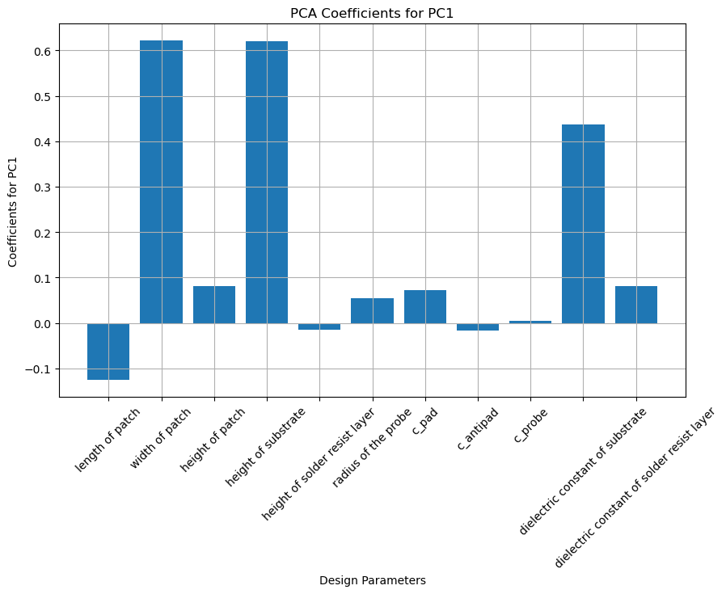

```python
coefficients = pd.DataFrame(
    pca.components_,
    columns=input_data.columns,
    index=[f"PC{i+1}" for i in range(len(pca.components_))]
)

# Identify the most important features for PC1
pc1_coeff = coefficients.loc["PC1"]
most_important_features_pc1 = pc1_coeff.abs().sort_values(ascending=False)
# Plot loadings for PC1
plt.figure(figsize=(10, 6))
plt.bar(coefficients.columns, pc1_coeff)
plt.xlabel("Design Parameters")
plt.ylabel("Coefficients for PC1")
plt.title("PCA Coefficients for PC1")
plt.xticks(rotation=45)
plt.grid()
plt.show()
```

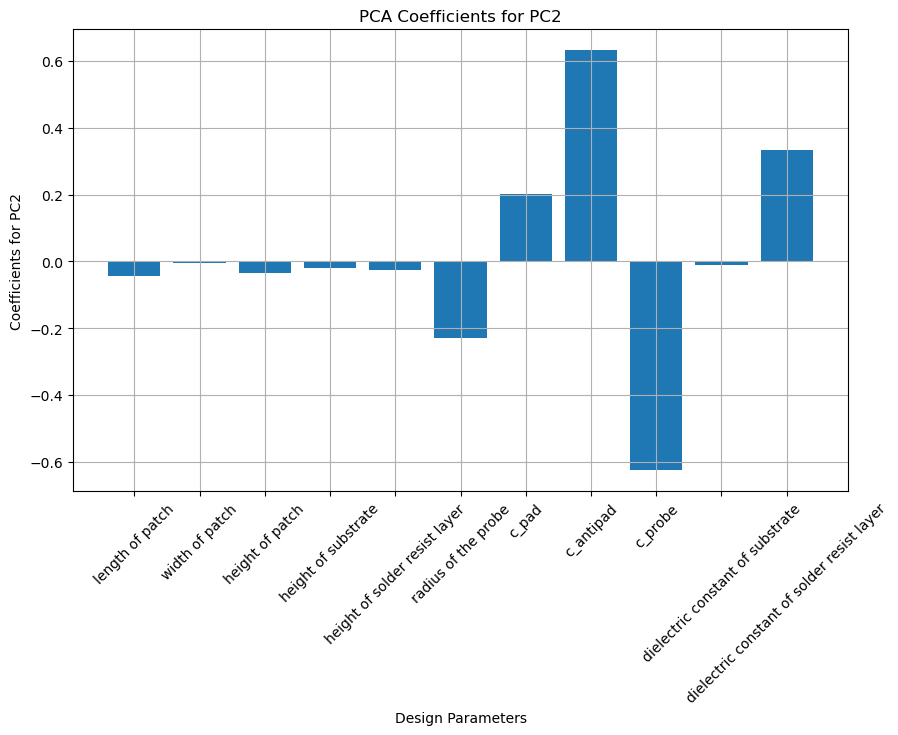

```python
pc2_coeff = coefficients.loc["PC2"]
most_important_features_pc2 = pc2_coeff.abs().sort_values(ascending=False)
plt.figure(figsize=(10, 6))
plt.bar(coefficients.columns, pc2_coeff)
plt.xlabel("Design Parameters")
plt.ylabel("Coefficients for PC2")
plt.title("PCA Coefficients for PC2")
plt.xticks(rotation=45)
plt.grid()
plt.show()
```

#### 3. Regression

##### For Real Part

```python
real_selected.columns = [f"Real_Freq_{i}" for i in selected_freq_indices]
img_selected.columns = [f"Imag_Freq_{i}" for i in selected_freq_indices]

real_selected.head()
```

|  | Real_Freq_70 | Real_Freq_120 |
| --- | --- | --- |
| 0 | -0.959924 | -0.965600 |
| 1 | -0.142208 | 0.008538 |
| 2 | -0.050536 | 0.724644 |
| 3 | -0.762386 | -0.649897 |
| 4 | -0.866825 | -0.799352 |

[figure not shown]

```python
# Combine input features and selected outputs
combined_data = pd.concat([input_data, real_selected, img_selected], axis=1)

# Compute the correlation matrix
correlation_matrix = combined_data.corr()

plt.figure(figsize=(12, 10))
sns.heatmap(
    correlation_matrix,
    annot=False,  # Set to True to see correlation values
    cmap="coolwarm",
    cbar=True
)
plt.title("Correlation Matrix of Design Parameters and Outputs")
plt.show()
```

According to the correlation matrix most correlated features for real part are width of patch and height of substrate, they are correlated with real part positively while for imaginary part they are negatively correlated. On the other hand, these two features are highly correlated with each other. So, for the model one of them could be enough. The relation between target(real or imaginary) and geometric features are shown below. It appears that width of patch and hight of substrate has a nonlinear relation with the target. So, applying linear regression may not be the answer.

[output not shown]

[output not shown]

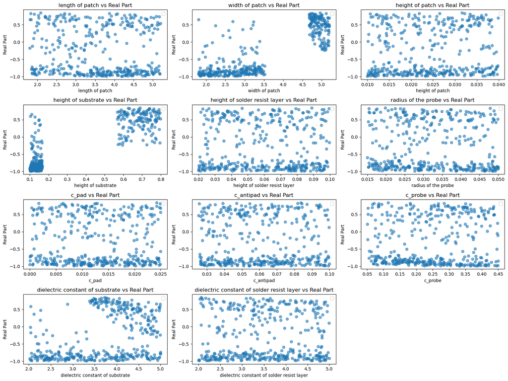

```python
plt.figure(figsize=(16, 12))
for i, column in enumerate(input_data.columns):
    plt.subplot(4, 3, i + 1)  # Adjust rows/cols based on the number of features
    plt.scatter(input_data[column], real_selected.iloc[:,0], alpha=0.6)
    #plt.scatter(input_data[column], img_mean, alpha=0.6, label='Mean Imaginary Part', color='orange')
    plt.title(f"{column} vs Real Part")
    plt.xlabel(column)
    plt.ylabel("Real Part")
    plt.legend()
    plt.tight_layout()

plt.show()
```

```python
# 7. Regression Modeling for Real Part of S11
real_model = LinearRegression()
real_model.fit(X_train, y_train_real)
y_pred_real = real_model.predict(X_test)

# Evaluate real part model
print("Real Part - Mean Squared Error:", mean_squared_error(y_test_real, y_pred_real))
print("Real Part - R^2 Score:", r2_score(y_test_real, y_pred_real))
```

```
Real Part - Mean Squared Error: 0.09408048092385574
Real Part - R^2 Score: 0.7663526689226714
```

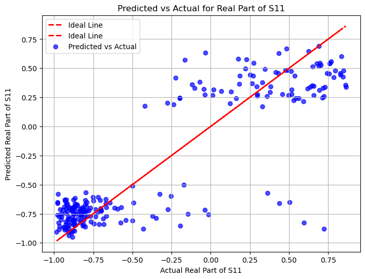

```python
# Scatter plot: Predicted vs Actual
plt.figure(figsize=(8, 6))
plt.scatter(y_test_real, y_pred_real, alpha=0.7, color='blue', label='Predicted vs Actual')
plt.plot([y_test_real.min(), y_test_real.max()], [y_test_real.min(), y_test_real.max()],
         color='red', linestyle='--', linewidth=2, label='Ideal Line')
plt.xlabel("Actual Real Part of S11")
plt.ylabel("Predicted Real Part of S11")
plt.title("Predicted vs Actual for Real Part of S11")
plt.legend()
plt.grid()
plt.show()
```

##### Imaginary Part

There is also a nonlinear relationship between imaginary part and the width of patch and height of substrate.

[output not shown]

[output not shown]

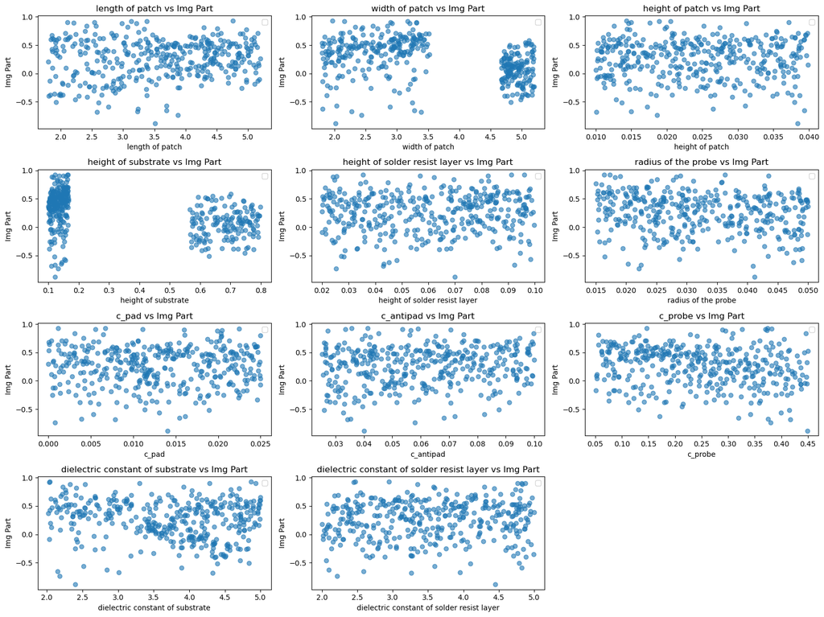

```python
plt.figure(figsize=(16, 12))
for i, column in enumerate(input_data.columns):
    plt.subplot(4, 3, i + 1)  # Adjust rows/cols based on the number of features
    plt.scatter(input_data[column], img_selected.iloc[:,0], alpha=0.6)
    #plt.scatter(input_data[column], img_mean, alpha=0.6, label='Mean Imaginary Part', color='orange')
    plt.title(f"{column} vs Img Part")
    plt.xlabel(column)
    plt.ylabel("Img Part")
    plt.legend()
    plt.tight_layout()

plt.show()
```

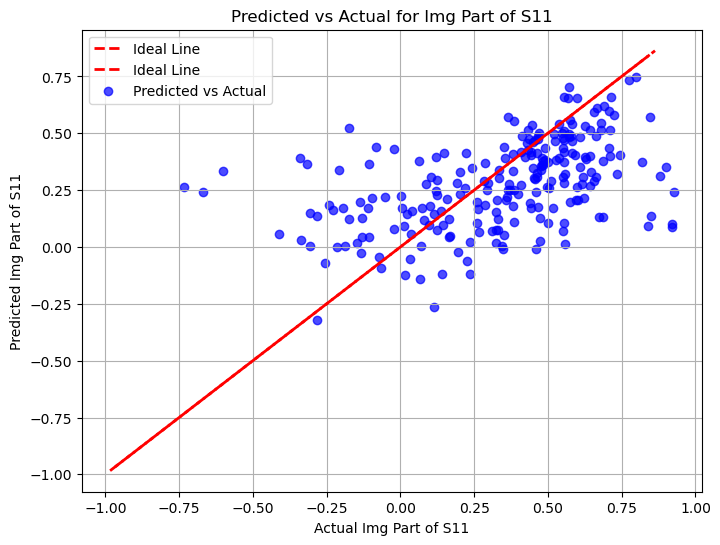

```python
img_model = LinearRegression()
img_model.fit(X_train, y_train_img)
y_pred_img = img_model.predict(X_test)

plt.figure(figsize=(8, 6))
plt.scatter(y_test_img, y_pred_img, alpha=0.7, color='blue', label='Predicted vs Actual')
plt.plot([y_test_real.min(), y_test_real.max()], [y_test_real.min(), y_test_real.max()],
         color='red', linestyle='--', linewidth=2, label='Ideal Line')
plt.xlabel("Actual Img Part of S11")
plt.ylabel("Predicted Img Part of S11")
plt.title("Predicted vs Actual for Img Part of S11")
plt.legend()
plt.grid()
plt.show()
```

```python
img_model = LinearRegression()
img_model.fit(X_train, y_train_img)
y_pred_img = img_model.predict(X_test)

# Evaluate imginary part model
print("imginary Part - Mean Squared Error:", mean_squared_error(y_test_img, y_pred_img))
print("imginary Part - R^2 Score:", r2_score(y_test_img, y_pred_img))
```

```
imginary Part - Mean Squared Error: 0.08220579093005698
imginary Part - R^2 Score: 0.16105609931580278
```

Results: According to the prediction vs actual plots, our models failed to fully capture the nonlinearity in the data which is expected. Because PCA and linear regression assume linear relationships between features and the target. However, for this example some of the features have nonlinearity. To deal with this problem nonlinear terms can be added to the model. Aldo other modelling approaches that more suitable for nonlinear problems may be helpful such as regression trees, boosting models etc.

Note: Some codes for the plots are edited using ChatGPT.